# SAGES - Predicting GCP slope

Author

Doug Tommet

Published

April 26, 2024

# Goals

## Overall goal

The overall goal is to build the two best prediction models for delirium and cognitive decline as possible given the data we collected. This is intended for a research audience because many of the variables going into this model would be difficult for clinicians to obtain.

## Today’s (2024-04-05) goal

Review the variables the expert panel voted to keep and the resulting principal compenent analysis.

## Today’s (2024-02-02) goal

Review the variables that made it through our selection process for inclusion into the model.

# Background

There are many interesting variables that could possibly included in our model. There are too many to reasonably include in any type of model given our sample size. So, we need a process to trim down our candidate variable list. The process we will use involves two (three?, four?) steps.

1. Variables with more than 50% missingness will be dropped. Those with less than 50% missingness will have values imputed using predictive mean matching.
2. Variables that lack any variability will be dropped. If a variable is an indicator for whether something happened, and only a few participants experienced the event, then even if the indicator is clinically meaningful, it will be dropped because it will make a poor predictor in the model.
3. Variables that are redundant with each other will be dropped. If a variable that can be reasonably well predicted by other variables in the model, then that variable is not providing much more to the model.
4. The remaining variables will be combined into principal components.

# Variable reduction

This section details the variable reduction technique from Harrell’s Regression Modeling Strategies that we used to reduce the number of variables used in the analysis.

Of the 128 variables we start with, we dropped 24 of them for having a low amount of variability.

These are the variables that were dropped:

| **Characteristic** | **N = 560**<sup>1</sup> |
| --- | --- |
| No Insurance |  |
| Insurance | 560 (100%) |
| No Insurance | 0 (0%) |
| Has Medicaid |  |
| No Medicaid | 552 (99%) |
| Medicaid | 8 (1.4%) |
| Evidence of Cognitive Impairment |  |
| No Cognitive Impairment | 558 (100%) |
| Cognitive Impairment (Chart) | 2 (0.4%) |
| Anesthesia: local |  |
| No | 543 (97%) |
| Yes | 17 (3.0%) |
| Anesthesia: midazolam |  |
| No | 539 (96%) |
| Yes | 21 (3.8%) |
| Anesthesia: remifentanil |  |
| No | 557 (99%) |
| Yes | 3 (0.5%) |
| Anesthesia: hydromorphone |  |
| No | 539 (96%) |
| Yes | 21 (3.8%) |
| Anesthesia: nitrous |  |
| No | 558 (100%) |
| Yes | 2 (0.4%) |
| Anesthesia: desflurane |  |
| No | 553 (99%) |
| Yes | 7 (1.3%) |
| Anesthesia: succinycholine |  |
| No | 554 (99%) |
| Yes | 6 (1.1%) |
| Anesthesia: vecuronium |  |
| No | 556 (99%) |
| Yes | 4 (0.7%) |
| Anesthesia: bupivacaine |  |
| No | 545 (97%) |
| Yes | 15 (2.7%) |
| Anesthesia: cefazolin |  |
| No | 542 (97%) |
| Yes | 18 (3.2%) |
| Anesthesia: ephedrine |  |
| No | 541 (97%) |
| Yes | 19 (3.4%) |
| Anesthesia: lidocaine |  |
| No | 551 (98%) |
| Yes | 9 (1.6%) |
| Anesthesia: mepivacaine |  |
| No | 559 (100%) |
| Yes | 1 (0.2%) |
| Anesthesia: neostigmine |  |
| No | 539 (96%) |
| Yes | 21 (3.8%) |
| Anesthesia: rocuronium |  |
| No | 545 (97%) |
| Yes | 15 (2.7%) |
| Anesthesia: vancomycin |  |
| No | 555 (99%) |
| Yes | 5 (0.9%) |
| Intraop complication - bradycardia requiring new permanent pacemaker |  |
| No | 559 (100%) |
| Yes | 1 (0.2%) |
| Intraop complication - uncontrolled bleeding |  |
| No | 558 (100%) |
| Yes | 2 (0.4%) |
| Intraop complication - prolonged severe hypotension |  |
| No | 555 (99%) |
| Yes | 5 (0.9%) |
| Intraop complication - other |  |
| No | 548 (98%) |
| Yes | 12 (2.1%) |
| Post-operative hypertension (SBP>140 or DBP>90) |  |
| No | 554 (99%) |
| Yes | 6 (1.1%) |

<sup>1</sup> n (%)

Of the 104 variables retained, 14 were dropped due to redundancy.

These are the variables that were dropped:

| **Characteristic** | **N = 560**<sup>1</sup> |
| --- | --- |
| Creatinine (mg/dL) (Pre-op) | 1.00 (0.32) |
| Bicarbonate mEq/L) (Pre-op) | 27.78 (2.64) |
| BUN (mg/dL) (POD1) | 18 (8) |
| Creatinine (mg/dL) (POD2) | 1.02 (0.52) |
| ASA class |  |
| ASA class:_1_2 | 207 (37%) |
| ASA class:_3_4 | 353 (63%) |
| Anesthesia Type |  |
| General Anesthesia only | 479 (86%) |
| Any Spinal Anesthesia | 81 (14%) |
| Anesthesia: general |  |
| No | 80 (14%) |
| Yes | 480 (86%) |
| Anesthesia time (ln(hours)) | 1.11 (0.35) |
| total Anticholinergic Drug Scale (ADS) score |  |
| 0 | 167 (30%) |
| 1 | 165 (29%) |
| 2 | 107 (19%) |
| 3 | 55 (9.8%) |
| 4 | 41 (7.3%) |
| 5 | 13 (2.3%) |
| 6 | 5 (0.9%) |
| 7 | 2 (0.4%) |
| 8 | 5 (0.9%) |
| number of medications contributing points to ADS score |  |
| 0 | 167 (30%) |
| 1 | 189 (34%) |
| 2 | 132 (24%) |
| 3 | 51 (9.1%) |
| 4 | 18 (3.2%) |
| 5 | 2 (0.4%) |
| 6 | 1 (0.2%) |
| Number of medications with ADS activity >1 |  |
| 0 | 467 (83%) |
| 1_2 | 93 (17%) |
| total Anticholinergic Cognitive Burden (ACB) scale score | 1.66 (1.70) |
| average ADS score per medication (computed as ACB/Num_med) | 0.21 (0.21) |
| ADS score if excluding medications scoring 1 on the ACB scale |  |
| 0 | 479 (86%) |
| 1 | 0 (0%) |
| 2 | 12 (2.1%) |
| 3 | 56 (10%) |
| 4_9 | 13 (2.3%) |

<sup>1</sup> Mean (SD); n (%)

### List of predictive features after dropping for missingness, low variance, and redundancy:

There are 90 variables retained after the redundancy analysis.

| variable | label |
| --- | --- |
| vdage | Age at This Visit |
| vdfemale | Female |
| vdnonwhite | Nonwhite |
| vdeduc_r | Respondent's Education, Years |
| vdlivesalone | Lives alone |
| vdsmokingstatus | Smoking status |
| vdmlta_metmins | MLTA |
| vdgcp_rta | Baseline GCP |
| wtar01 | WTAR |
| vdadlany | ADL (any) |
| vdiadlanyc | IADL cognitive (any) |
| vdgds15 | Geriatric Depression Scale Score (/15 Points) |
| vdsf12pcs | SF12 physical composite T-score |
| vdsf12mcs | SF12 mental composite T-score |
| vdfriedfrail2 | Frailty - Exhaustion |
| vdfriedfrail3 | Frailty - Low Physical Activity |
| vdsurg | Surgery |
| vdcrp_preop | CRP - preop |
| vdcrp_pod2 | CRP - POD2 |
| vd3ms | 3MS Score |
| vdbmi3 | BMI |
| vdesl | English is second language |
| apoe4 | APOE 4 |
| vdiqc_proxy | IQCODE, Proxy Report |
| vdcci | Charlson Comorbidity Index |
| vdvascom | Vascular Comorbidity |
| vdapache | Postoperative APACHE II Score |
| ins02 | Has Medicare |
| ins03 | Has Private Insurance |
| ins05 | Has Other Insurance |

[output cut: 60 more lines]

## Principal component analysis

After the redundancy analysis, several versions of a principal components analysis was done that made linear combinations of various groupings of the remaining variables.

Prior to the PCA factor variables were turned into dummy indicator variables and then all variables were centered and scaled.

### Complete variable set

There are 92 variables and thus principal components in total.

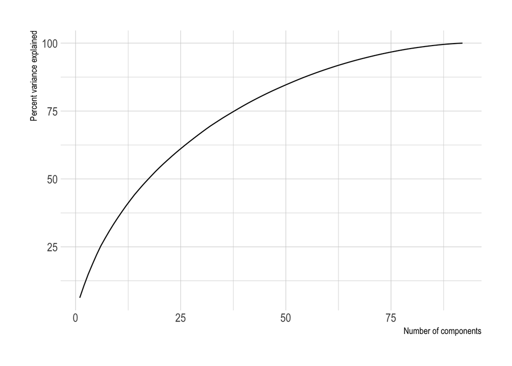

Amount of variance explained by the prinicpal components

`

The first 15 components explain 46 percent of the variance.

### Expert panel variable sets

After the previous PCA showed that the first several principal components don’t explain as much variance as expected, the expert panel voted on which variables to keep. These are the results.

| Variable | Label | Expert panel Received 3+ votes | Expert panel Received 2+ votes | Expert panel Received 1+ votes |
| --- | --- | --- | --- | --- |
| vdage | Age at This Visit | TRUE | TRUE | TRUE |
| vdeduc_r | Respondent's Education, Years | TRUE | TRUE | TRUE |
| vdgcp_rta | Baseline GCP | TRUE | TRUE | TRUE |
| vdiadlanyc | IADL cognitive (any) | TRUE | TRUE | TRUE |
| vdcci | Charlson Comorbidity Index | TRUE | TRUE | TRUE |
| vdp41721 | antipsychotics use in days 1-7 | TRUE | TRUE | TRUE |
| vdp43301 | (icu01 recode) Was the patient ever in the ICU or CCU? | TRUE | TRUE | TRUE |
| vdfemale | Female | FALSE | TRUE | TRUE |
| vdsf12pcs | SF12 physical composite T-score | FALSE | TRUE | TRUE |
| vdsurg | Surgery | FALSE | TRUE | TRUE |
| vdapache | Postoperative APACHE II Score | FALSE | TRUE | TRUE |
| vdp41508 | total number of pre-hospital medications in patient's record | FALSE | TRUE | TRUE |
| vdnonwhite | Nonwhite | FALSE | FALSE | TRUE |
| vdlivesalone | Lives alone | FALSE | FALSE | TRUE |
| wtar01 | WTAR | FALSE | FALSE | TRUE |
| vdadlany | ADL (any) | FALSE | FALSE | TRUE |
| vdgds15 | Geriatric Depression Scale Score (/15 Points) | FALSE | FALSE | TRUE |
| apoe4 | APOE 4 | FALSE | FALSE | TRUE |
| ins03 | Has Private Insurance | FALSE | FALSE | TRUE |
| lab01a | WBC (x103) (Pre-op) | FALSE | FALSE | TRUE |
| lab05a | Sodium (mEq/L) (Pre-op) | FALSE | FALSE | TRUE |
| lab15c | O2 saturation (%) (POD1) | FALSE | FALSE | TRUE |
| lab.bun.cre.ratio.1 | BUN/creatinine ratio (Pre-op) | FALSE | FALSE | TRUE |
| op01_3 | ASA class | FALSE | FALSE | TRUE |
| vdp41504 | Presence of benzodiazepine in pre-hospital medication list | FALSE | FALSE | TRUE |
| vdp41509 | average ADS score per medication (computed as score/Med_num) | FALSE | FALSE | TRUE |
| vdp41515 | Number of medications with ACB activity >1 | FALSE | FALSE | TRUE |
| vdp41722 | benzodiazepines use in days 1-7 | FALSE | FALSE | TRUE |
| vdp43101 | Days from surgery to first ambulation | FALSE | FALSE | TRUE |

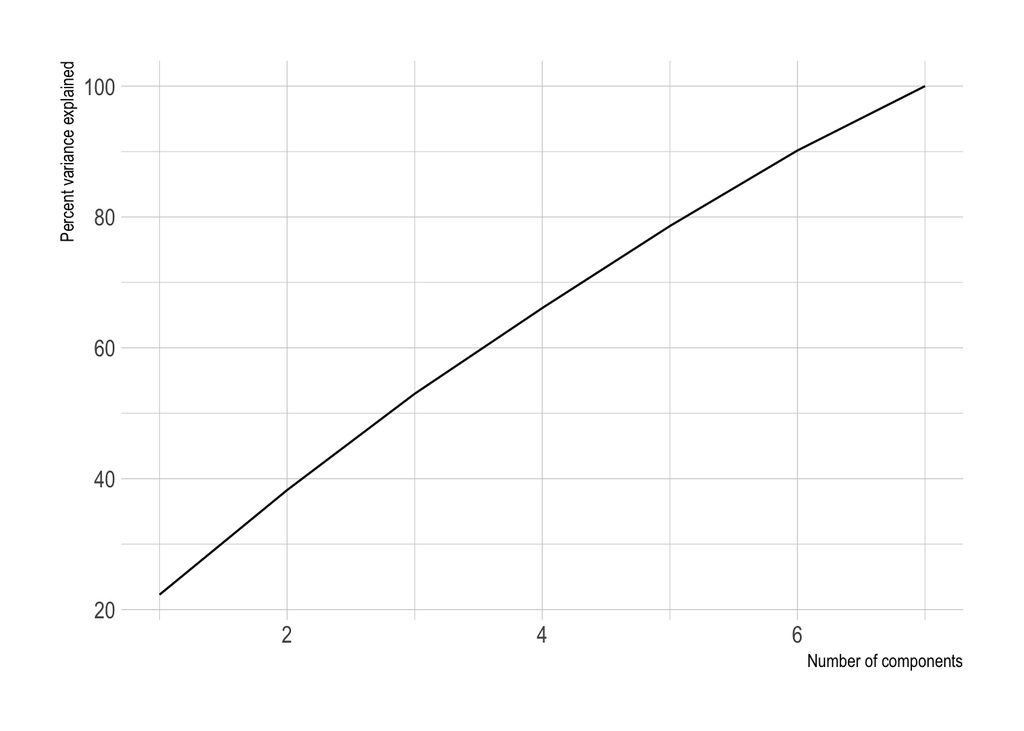

Amount of variance explained by the prinicpal components (3+ votes by expert panel)

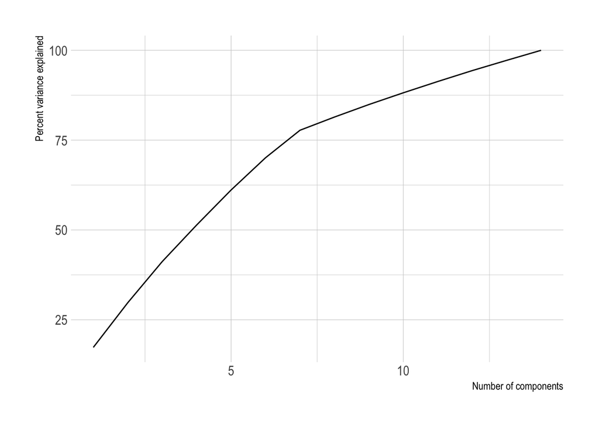

Amount of variance explained by the prinicpal components (2+ votes by expert panel)

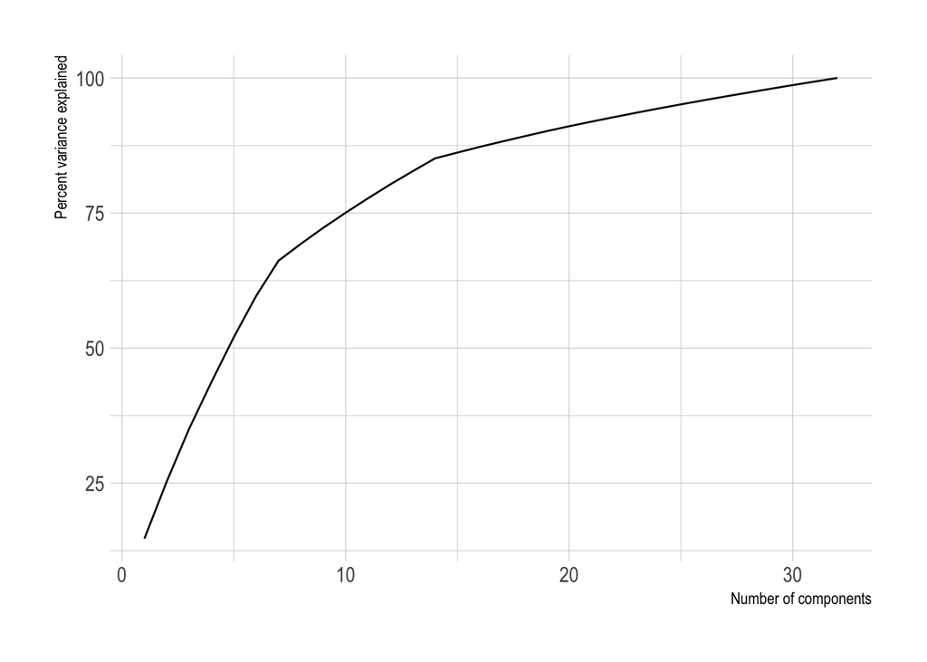

Amount of variance explained by the prinicpal components (1+ votes by expert panel)

# Modeling

The models fit are:

- Elastic net

# Fitting the models

The elastic net models were fit on four variable sets:

- The first 15 PCA components from the set of 93 variables.
- The set of 7 PCA components from the 7 variables that had three or more votes from the expert panel
- The set of 14 PCA components from the 14 variables that had two or more votes from the expert panel
- The first 15 PCA components from the 32 variables that had one or more votes from the expert panel

**Model tuning**

The training data was into 10 cross-validation sets.

The elastic net models were tuned using 25 sets of possible values.

These are the hyperparameters that were tuned:

These are the hyperparameters that have the best RMSE for the elastic net model:

Model using the first 15 of 93 PCA components.

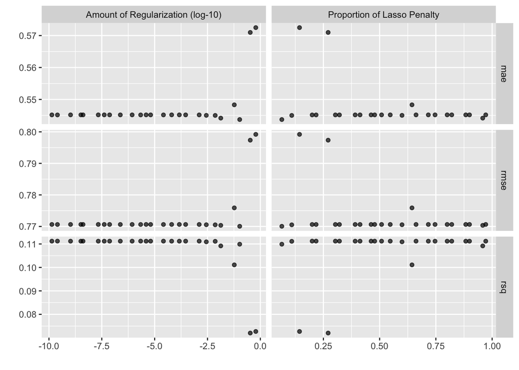

```
# A tibble: 5 × 8
   penalty mixture .metric .estimator  mean     n std_err .config
     <dbl>   <dbl> <chr>   <chr>      <dbl> <int>   <dbl> <chr>
1 1.06e- 1  0.0653 rmse    standard   0.770    10  0.0479 Preprocessor1_Model01
2 1.34e- 2  0.958  rmse    standard   0.770    10  0.0481 Preprocessor1_Model24
3 7.32e- 3  0.109  rmse    standard   0.771    10  0.0483 Preprocessor1_Model02
4 2.78e- 3  0.600  rmse    standard   0.771    10  0.0483 Preprocessor1_Model15
5 2.52e-10  0.200  rmse    standard   0.771    10  0.0483 Preprocessor1_Model04
```

Model using the 7 PCA components from variables that had three or more votes from the expert panel.

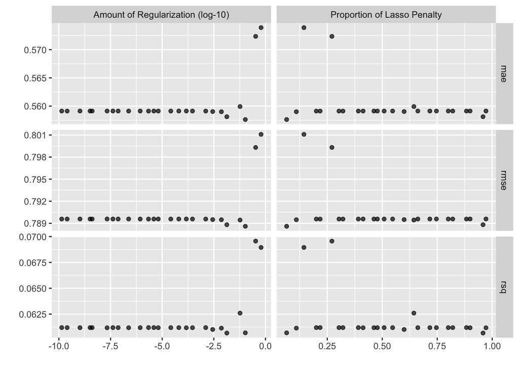

```
# A tibble: 5 × 8
  penalty mixture .metric .estimator  mean     n std_err .config
    <dbl>   <dbl> <chr>   <chr>      <dbl> <int>   <dbl> <chr>
1 0.106    0.0653 rmse    standard   0.789    10  0.0448 Preprocessor1_Model01
2 0.0134   0.958  rmse    standard   0.789    10  0.0450 Preprocessor1_Model24
3 0.0586   0.644  rmse    standard   0.789    10  0.0458 Preprocessor1_Model16
4 0.00732  0.109  rmse    standard   0.789    10  0.0446 Preprocessor1_Model02
5 0.00278  0.600  rmse    standard   0.790    10  0.0446 Preprocessor1_Model15
```

Model using the 14 PCA components from variables that had two or more votes from the expert panel.

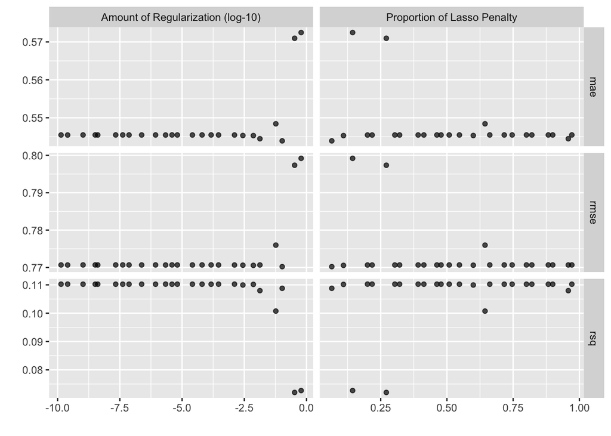

```
# A tibble: 5 × 8
   penalty mixture .metric .estimator  mean     n std_err .config
     <dbl>   <dbl> <chr>   <chr>      <dbl> <int>   <dbl> <chr>
1 1.06e- 1  0.0653 rmse    standard   0.770    10  0.0479 Preprocessor1_Model01
2 7.32e- 3  0.109  rmse    standard   0.771    10  0.0482 Preprocessor1_Model02
3 2.78e- 3  0.600  rmse    standard   0.771    10  0.0482 Preprocessor1_Model15
4 2.18e- 6  0.218  rmse    standard   0.771    10  0.0483 Preprocessor1_Model05
5 2.52e-10  0.200  rmse    standard   0.771    10  0.0483 Preprocessor1_Model04
```

Model using the first 15 of 32 PCA components from variables that had one or more votes from the expert panel.

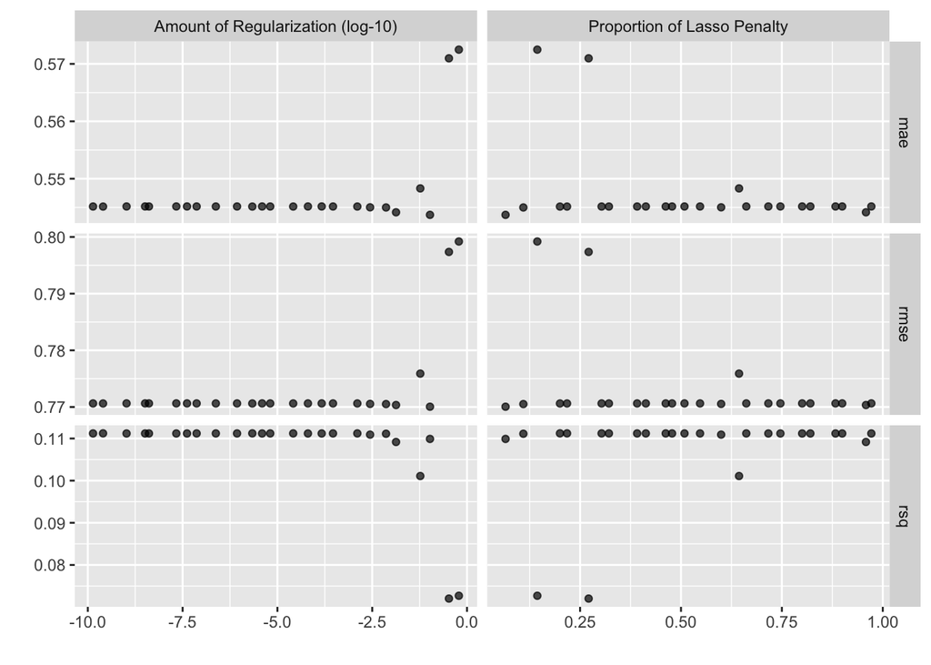

```
# A tibble: 5 × 8
   penalty mixture .metric .estimator  mean     n std_err .config
     <dbl>   <dbl> <chr>   <chr>      <dbl> <int>   <dbl> <chr>
1 1.06e- 1  0.0653 rmse    standard   0.770    10  0.0479 Preprocessor1_Model01
2 1.34e- 2  0.958  rmse    standard   0.770    10  0.0481 Preprocessor1_Model24
3 7.32e- 3  0.109  rmse    standard   0.771    10  0.0483 Preprocessor1_Model02
4 2.78e- 3  0.600  rmse    standard   0.771    10  0.0483 Preprocessor1_Model15
5 2.52e-10  0.200  rmse    standard   0.771    10  0.0483 Preprocessor1_Model04
```

# Performance in testing set

## Elastic net

Model using the first 15 of 93 PCA components.

```
# A tibble: 2 × 4
  .metric .estimator .estimate .config
  <chr>   <chr>          <dbl> <chr>
1 rmse    standard       0.708 Preprocessor1_Model1
2 rsq     standard       0.109 Preprocessor1_Model1
```

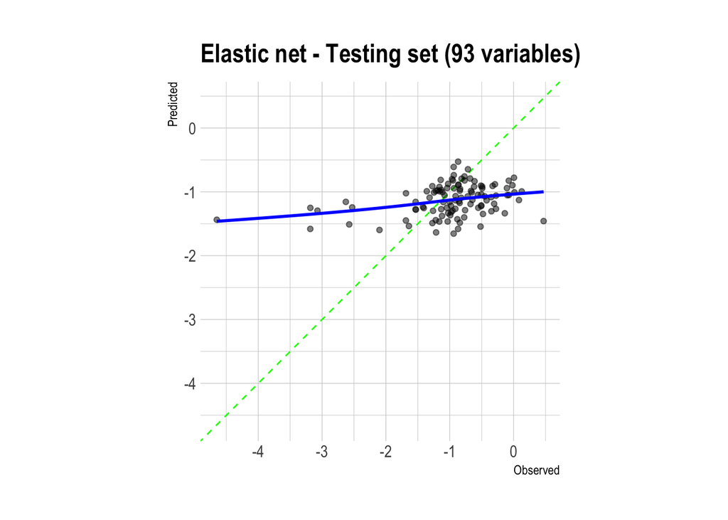

Model using the 7 PCA components from variables that had three or more votes from the expert panel.

```
# A tibble: 2 × 4
  .metric .estimator .estimate .config
  <chr>   <chr>          <dbl> <chr>
1 rmse    standard      0.728  Preprocessor1_Model1
2 rsq     standard      0.0659 Preprocessor1_Model1
```

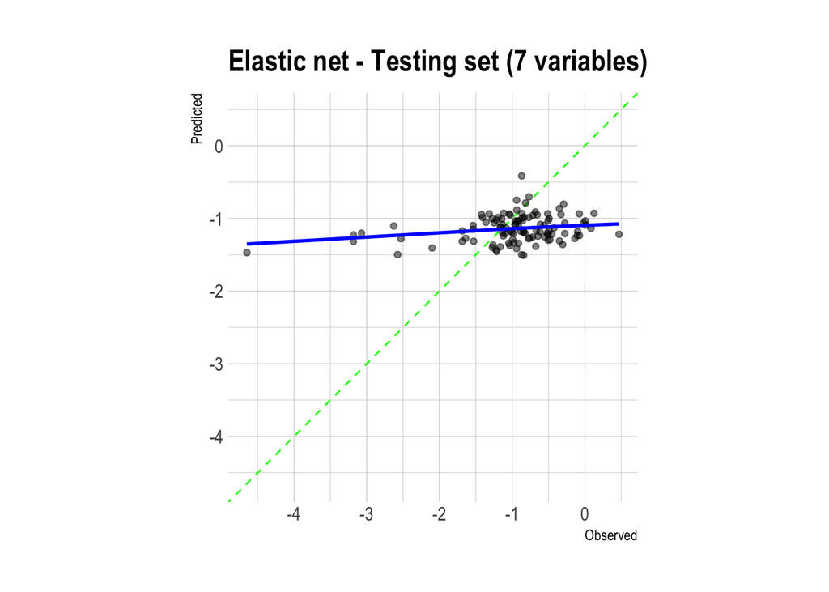

Model using the 14 PCA components from variables that had two or more votes from the expert panel.

```
# A tibble: 2 × 4
  .metric .estimator .estimate .config
  <chr>   <chr>          <dbl> <chr>
1 rmse    standard       0.707 Preprocessor1_Model1
2 rsq     standard       0.113 Preprocessor1_Model1
```

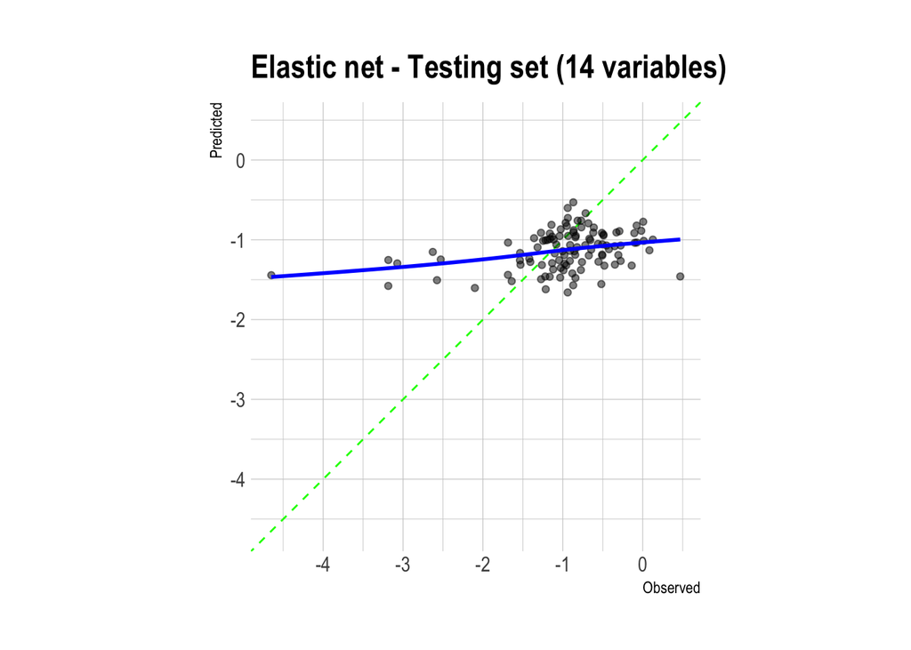

Model using the first 15 of 32 PCA components from variables that had one or more votes from the expert panel.

```
# A tibble: 2 × 4
  .metric .estimator .estimate .config
  <chr>   <chr>          <dbl> <chr>
1 rmse    standard       0.708 Preprocessor1_Model1
2 rsq     standard       0.109 Preprocessor1_Model1
```

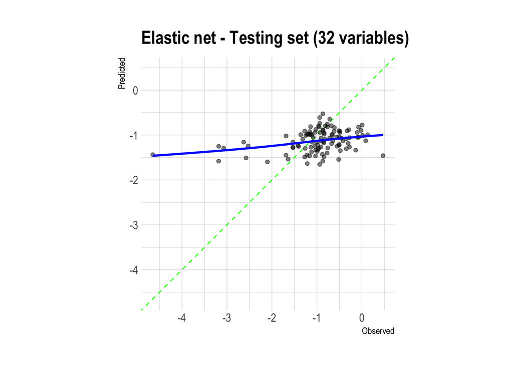